[figure not shown]

# Exploratory Data Analysis

- **Exploratory Data Analysis** involves two fundamental steps:
  - **Data Analysis** (Data Pre processing, Cleaning and Manipulation).
  - **Data Visualisation** (Visualise relationships in data using different types of plots).
- **Pandas** is the most commonly used library for data analysis in **Python**.
- There are tons of libraries available in python for **data visualisation** and among them.
  - **Matplotlib** is the most commonly used.
- **Matplotlib** provides full control over the plot to make plot customisation easy.
  - But what it lacks is built in support for pandas.
- **Seaborn** is a data visualisation library built on top of **matplotlib** and closely integrated with **pandas**.

# We will cover:

- Different types of plots available in **seaborn**.
- How the integration of **pandas** with **seaborn** helps in making complex multidimensional plots with minimal code?
- How to customise plots made using **seaborn**, with the help of **matplotlib**?

[figure not shown]

# Matplotlib

- Although many tasks can be accomplished using just the **seaborn** functions, it is essential to understand the basics of **matplotlib** for two main reasons:
  - Behind the scenes, **seaborn** uses **matplotlib** to draw the plots.
  - Some customisation might require direct use of **matplotlib**.
- Here is a quick review of **matplotlib** basics. The following figure shows the anatomy of a **matplotlib** Figure.

[figure not shown]

# Figure, Axes and Axis

## Figure

It refers to the whole figure that you see. It is possible to have multiple sub-plots (Axes) in the same figure. In the below example, we have four sub-plots (Axes) in a single figure.

## Axes

An Axes refers to the actual plot in the figure. A figure can have multiple Axes but a given Axes can be part of only one figure. In the below example, we have four Axes in one Figure.

## Axis

An Axis refers to an actual axis (x-axis/y-axis) in a specific plot.

[figure not shown]

```python
import pandas as pd
import numpy as np
from matplotlib import pyplot as plt
import seaborn as sns
sns.set_style("whitegrid")
%matplotlib inline
%matplotlib notebook
import warnings
warnings.filterwarnings('ignore')
tips = sns.load_dataset('tips')
iris = sns.load_dataset('iris')
```

```python
tips.head()
```

|  | total_bill | tip | sex | smoker | day | time | size |
| --- | --- | --- | --- | --- | --- | --- | --- |
| 0 | 16.99 | 1.01 | Female | No | Sun | Dinner | 2 |
| 1 | 10.34 | 1.66 | Male | No | Sun | Dinner | 3 |
| 2 | 21.01 | 3.50 | Male | No | Sun | Dinner | 3 |
| 3 | 23.68 | 3.31 | Male | No | Sun | Dinner | 2 |
| 4 | 24.59 | 3.61 | Female | No | Sun | Dinner | 4 |

```python
iris.head()
```

|  | sepal_length | sepal_width | petal_length | petal_width | species |
| --- | --- | --- | --- | --- | --- |
| 0 | 5.1 | 3.5 | 1.4 | 0.2 | setosa |
| 1 | 4.9 | 3.0 | 1.4 | 0.2 | setosa |
| 2 | 4.7 | 3.2 | 1.3 | 0.2 | setosa |
| 3 | 4.6 | 3.1 | 1.5 | 0.2 | setosa |
| 4 | 5.0 | 3.6 | 1.4 | 0.2 | setosa |

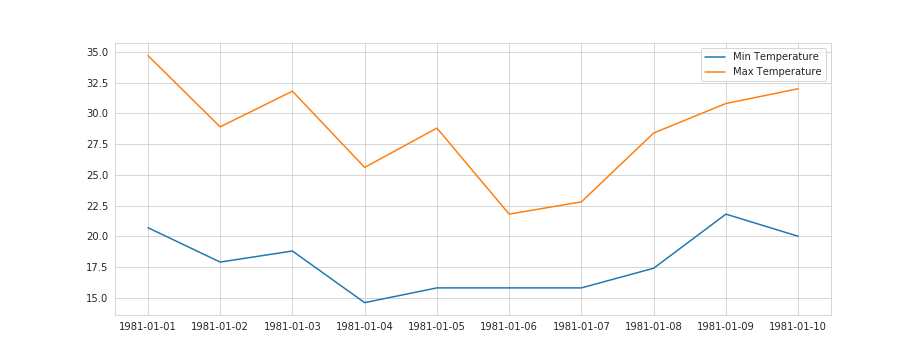

```python
dates = ['1981-01-01', '1981-01-02', '1981-01-03', '1981-01-04', '1981-01-05',
        '1981-01-06', '1981-01-07', '1981-01-08', '1981-01-09', '1981-01-10']
min_temperature = [20.7, 17.9, 18.8, 14.6, 15.8, 15.8, 15.8, 17.4, 21.8, 20.0]
max_temperature = [34.7, 28.9, 31.8, 25.6, 28.8, 21.8, 22.8, 28.4, 30.8, 32.0]

fig,axes = plt.subplots(nrows=1, ncols=1, figsize=(13,5))
# plt.subplots() creates a single Figure instance,
# (nrows * ncols) Axes instances and returns the created Figure and Axes instances .
# Since we have passed nrows=1 and ncols=1, it creates only a single Axes instance.
# If nrows > 1 or ncols > 1, it creates a grid of Axes
# and returns them in an (nrows * ncols) shaped numpy array.

axes.plot(dates, min_temperature, label='Min Temperature')
axes.plot(dates, max_temperature, label = 'Max Temperature')
axes.legend()
plt.show()
```

# Most frequently used methods of Axes class for customisation:

```
Axes.set_xlabel()
Axes.set_ylabel()
Axes.set_xlim()
Axes.set_ylim()
Axes.set_xticks()
Axes.set_yticks()
Axes.set_xticklabels()
Axes.set_yticklabels()
Axes.set_title()
Axes.tick_params()
```

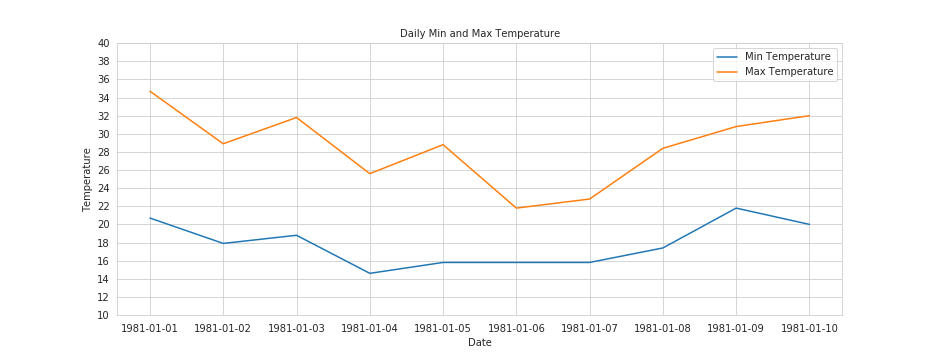

```python
fontsize = 10
fig,axes = plt.subplots(nrows=1, ncols=1, figsize=(13,5))
#fig,axes = plt.subplots(nrows=1, ncols=1)
axes.plot(dates, min_temperature, label='Min Temperature')
axes.plot(dates, max_temperature, label='Max Temperature')

axes.set_xlabel('Date',fontsize=fontsize)
axes.set_ylabel('Temperature',fontsize=fontsize)

axes.set_title('Daily Min and Max Temperature',fontsize=fontsize)

axes.set_xticks(dates)
axes.set_xticklabels(dates)
axes.tick_params('x', labelsize=fontsize, labelrotation=0, size=5)


axes.set_ylim(10,40)
axes.set_yticks(np.arange(10,41,2))
axes.tick_params('y',labelsize=fontsize)

axes.legend(fontsize=fontsize,loc='best', bbox_to_anchor=(1,1))
```

# Seaborn

- Each plotting function in seaborn is either a **figure-level** function or an **Axes-level** function, and it is essential to understand the difference between the two.
- As mentioned earlier, a **Figure** refers to the whole figure that you see, where as an **Axes** refers to a specific subplot in the figure.
- An **Axes-level** function draws onto a single matplotlib Axes and does not effect the rest of the figure.
- A **figure-level** function, on the other hand, controls the entire figure.
- One way to think about this is, a **figure-level** function can call different **Axes-level** functions to draw different types of subplots on different Axes

# Seaborn: Axes Level Functions

- **Relational Plots**

  > `scatterplot()`  
  > `lineplot()`
- **Categorical Plots**

  > `striplot()`  
  > `swarmplot()`  
  > `boxplot()`  
  > `boxenplot()`  
  > `violinplot()`  
  > `countplot()`  
  > `pointplot()`  
  > `barplot()`
- **Distribution Plots**

  > `distplot()`  
  > `kdeplot()`  
  > `rugplot()`
- **Regression Plots**

  > `regplot()`  
  > `residplot()`
- **Matrix Plots**

  > `heatmap()`

**There are two main things to understand to use any Axes-level function**

- Different ways to give input data to the Axes-level function.
- Specifying the Axes to be used to make the plot.

# Seaborn: Axes Level Functions

## 3 Different Ways to give input data to the Axes-level function

### 1. Lists, Arrays or Series

- The most common way to pass data to an **Axes-level** function is using iterables like **lists**, **arrays** or **series**

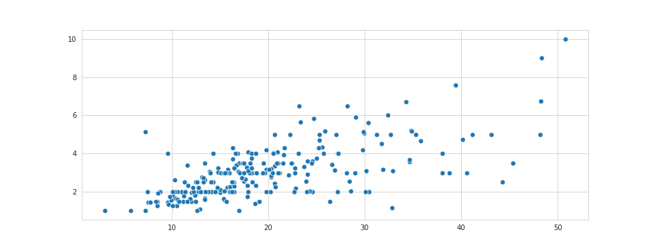

```python
fig,axes = plt.subplots(nrows=1, ncols=1, figsize=(13,5))
total_bill = tips['total_bill'].values
tip = tips['tip'].values
sns.scatterplot(total_bill, tip, s=50)
```

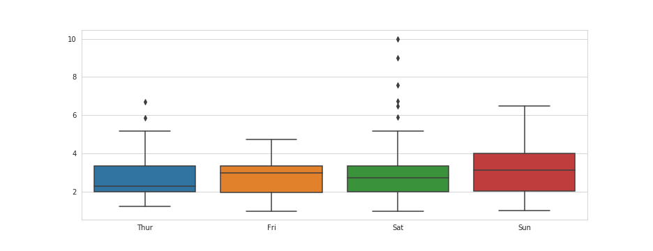

```python
fig,axes = plt.subplots(nrows=1, ncols=1, figsize=(13,5))
tip = tips['tip'].values
day = tips['day'].values
sns.boxplot(day, tip)
```

# Seaborn: Axes Level Functions

## 3 Different Ways to give input data to the Axes-level function

### 2. Using pandas Dataframe and names of columns

- One of the main reasons for **seaborn**’s popularity is its ability to directly work with **pandas** **Dataframes**. In this method for passing data, column names should be passed to **x** and **y** parameters and Dataframe should be passed to **data** parameter

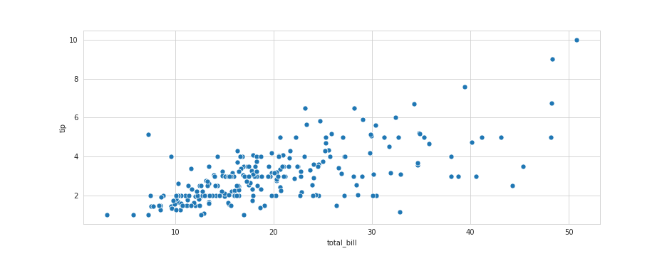

```python
fig,axes = plt.subplots(nrows=1, ncols=1, figsize=(13,5))
sns.scatterplot(x='total_bill',y='tip', data=tips, s=50)
```

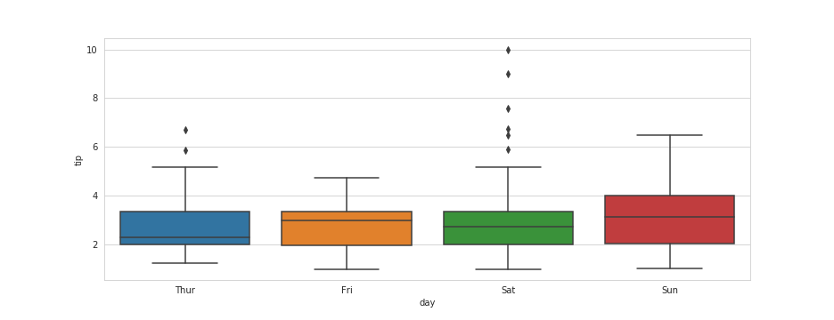

```python
fig,axes = plt.subplots(nrows=1, ncols=1, figsize=(13,5))
sns.boxplot(x='day', y='tip', data=tips)
```

# Seaborn: Axes Level Functions

## 3 Different Ways to give input data to the Axes-level function

### 3 Passing only the Dataframe

- In this method for passing data, only the **Dataframe** is passed to **data** parameter. Each numeric column in the dataset will be plotted using this method. This method can be used only with following **Axes-level** functions:

  > `stripplot()`  
  > `swarmplot()`  
  > `boxplot()`  
  > `boxenplot()`  
  > `violinplot()`  
  > `pointplot()`  
  > `barplot()`  
  > `countplot()`
- A specific use case for this method of passing input data is comparing the distribution of multiple numeric variables in a dataset, using any of the above mentioned **Axes-level** functions

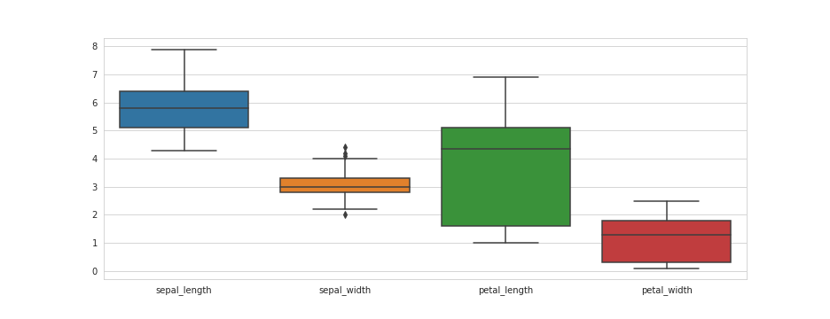

```python
fig,axes = plt.subplots(nrows=1, ncols=1, figsize=(13,5))
sns.boxplot(data=iris)
```

# Seaborn: Axes Level Functions

## Specifying the axes to be used to make the plot

- Each **Axes-level** function in **seaborn** takes an explicit **ax** argument.
- The Axes passed to the **ax** argument will be then used to make the plot.
- This provides great flexibility in terms of controlling which **Axes** is to be used for plotting.
- For example, let’s say we want to look at the relationship between **total bill** and **tip** (using a **scatter plot**) as well as their distribution (using **box plot**) in the same figure but on different **Axes**.

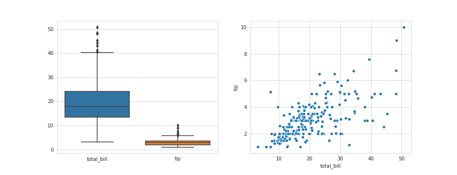

```python
fig,axes = plt.subplots(nrows=1, ncols=2, figsize=(13,5))
sns.scatterplot(x='total_bill', y='tip', data=tips, ax=axes[1])
sns.boxplot(data = tips[['total_bill','tip']],ax=axes[0])
```

# Seaborn: Axes Level Functions

## Specifying the axes to be used to make the plot

- Each **Axes-level** function also returns the **Axes** on which the plot has been made. If an **Axes** has been passed to **ax** argument the same **Axes** object will be returned.
- The returned **Axes** object can then be used for further customisation using different methods like `Axes.set_xlabel()`, `Axes.set_ylabel()` etc.
- If no **Axes** is passed to the **ax** argument, seaborn uses the current (active) **Axes** to make the plot.

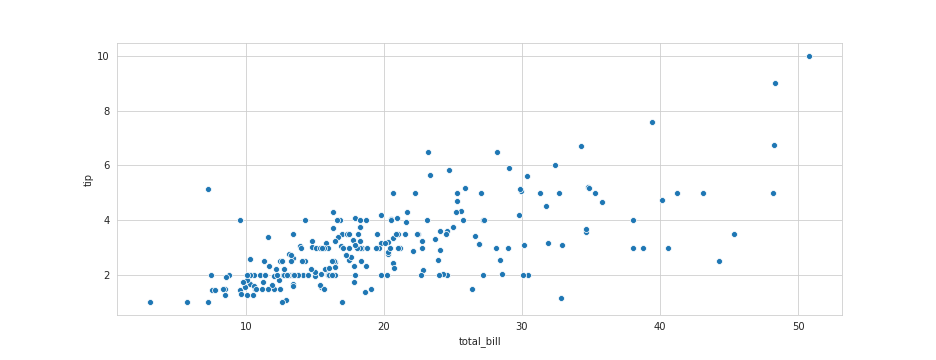

```
True
```

```python
fig,curr_axes = plt.subplots(nrows=1, ncols=1, figsize=(13,5))
scatter_plot_axes = sns.scatterplot(x='total_bill', y='tip', data=tips)
id(curr_axes) == id(scatter_plot_axes)
```

# Seaborn: Axes Level Functions

## Specifying the axes to be used to make the plot

- In the above example even though we haven’t explicitly passed **curr_axes** (currently active axes) to **ax** argument, **seaborn** still uses it to make the plot, since it is the currently active Axes.
- `id(curr_axes) == id(scatter_plot_axes)` returns **True** indicating that they are the same **Axes**.
- If no **Axes** is passed to **ax** argument and there is no currently active Axes object, **seaborn** creates a new **Axes** object to make the plot and then returns that **Axes** object
- The **Axes-level** functions in **seaborn** do not have any direct parameter to control the figure size.
- However, since we can specify which **Axes** is to be used for plotting, by passing the **Axes** in **ax** argument, we can control the figure size as follows:

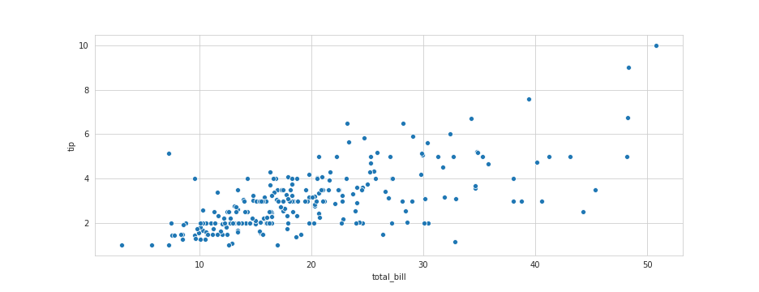

```python
fig,axes = plt.subplots(1, 1, figsize=(13,5))
sns.scatterplot(x='total_bill', y='tip', data=tips, ax=axes)
```

# Seaborn: Figure Level Functions

- When exploring a multi dimensional dataset, one of the most common use case for data visualisation, is drawing multiple instances of same plot on different subsets of data.
- The **figure-level** functions in **seaborn** are tailor made for this use case.
- A **figure-level** function has complete control over the entire figure and each time a **figure-level** function is called, it creates a new figure which can include multiple **Axes**, all organised in a meaningful way.
- The three most generic **figure-level** functions in seaborn are `FacetGrid`, `PairGrid`, `JointGrid`

# Seaborn: Figure Level Functions

## FacetGrid

- Consider a following use case, we want to visualise the relationship between **total_bill** and **tip** (via a **scatter plot**) on different subsets of data. Each subset of data is categorised by a unique combination of values for following variables:
  - day (Thur, Fri, Sat, Sun)
  - smoker (whether the person is a smoker or not)
  - sex (male or female)

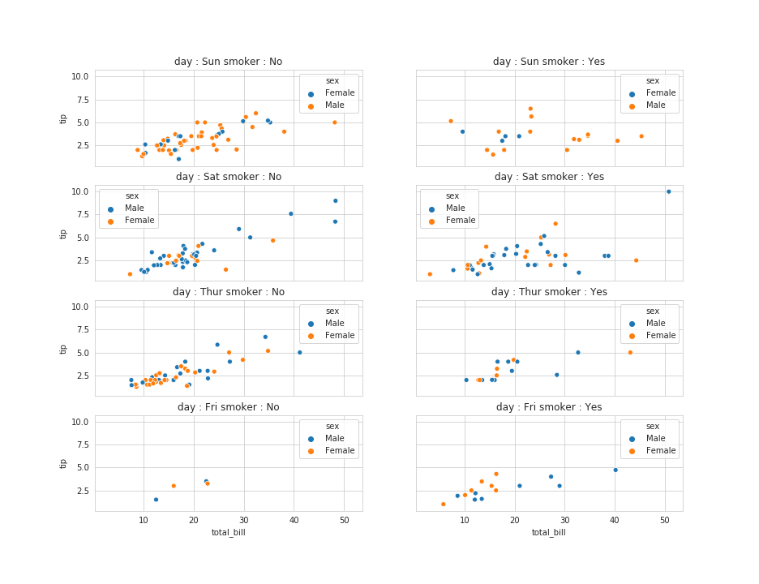

```python
row_variable = 'day'
col_variable = 'smoker'
hue_variable = 'sex'
row_variables = tips[row_variable].unique()
col_variables = tips[col_variable].unique()
num_rows = row_variables.shape[0]
num_cols = col_variables.shape[0]

fig,axes = plt.subplots(num_rows, num_cols, sharex=True, sharey=True, figsize=(13,10))
subset = tips.groupby([row_variable,col_variable])
for row in range(num_rows):
    for col in range(num_cols):
        ax = axes[row][col]
        row_id = row_variables[row]
        col_id = col_variables[col]
        ax_data = subset.get_group((row_id, col_id))
        sns.scatterplot(x='total_bill', y='tip', data=ax_data, hue=hue_variable, ax=ax)
        title = row_variable + ' : '  + row_id + ' ' + col_variable + ' : ' + col_id
        ax.set_title(title)
```

# Seaborn: Figure Level Functions

## FacetGrid

- The above code can be broken down into three steps:
  - Create an Axes (subplot) for each subset of data
  - Divide the dataset into subsets
  - On each Axes, draw the scatter plot using subset of data corresponding to that Axes
- Step 1 can be done in seaborn using `FacetGrid()`
- Step 2 and Step 3 can be done using `FacetGrid.map()`
- Using `FacetGrid`, we can create **Axes** for dividing the dataset upto three dimensions using `row`, `col` and `hue` parameters.
- Once we have created a `FacetGrid`, we can plot the same kind of plot on all **Axes** using `FacetGrid.map()` by passing the type of plot as an argument. We also need to pass the name of columns to be used for plotting.

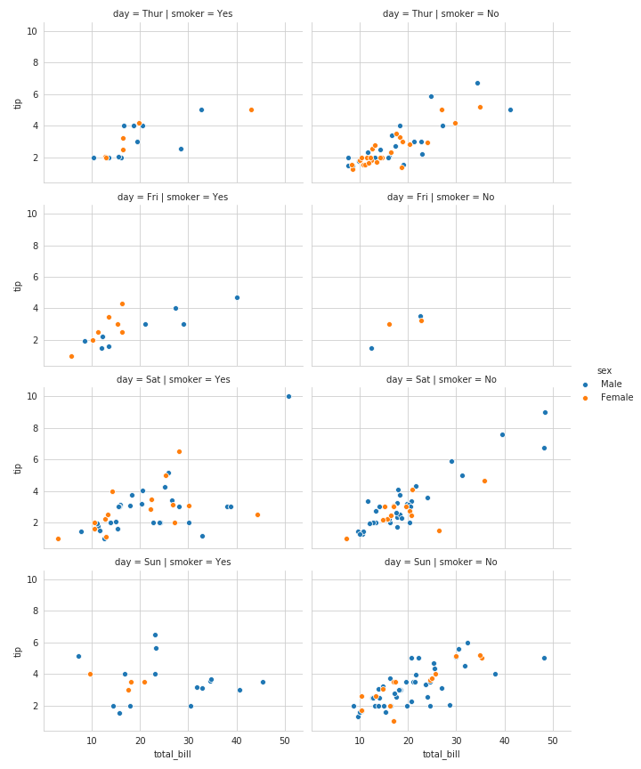

```python
facet_grid = sns.FacetGrid(row='day', col='smoker', hue='sex',
                           data=tips, height=3, aspect=1.5)
facet_grid.map(sns.scatterplot, 'total_bill','tip')
facet_grid.add_legend()
```

# Seaborn: Figure Level Functions

## FacetGrid

- Thus **Matplotlib** offers good support to make plots with multiple **Axes** but **seaborn** builds on top of it by directly linking the structure of plot with the structure of dataset”.
- Using `FacetGrid`, we neither have to explicitly create **Axes** for each subset nor do we have to explicitly divide the data into subsets. That is done internally by `FacetGrid()` and `FacetGrid.map()` respectively.
- We can pass different Axes level function to FacetGrid.map().
- Also, **seaborn** provides three **Figure-Level** functions (high level interfaces) which use `FacetGrid()` and `FacetGrid.map()` in the background:

  > `relplot()`  
  > `catplot()`  
  > `lmplot()`
- Each of the above **figure-level** function use `FacetGrid()` to create multiple **Axes**, and take an **Axes-level** function in `kind` argument, which is then passed to `FacetGrid.map()` internally.
- So the above three functions are different in terms of what **Axes-level** functions can be passed to each one of them:

> `relplot()`

> > `FacetGrid()` + `lineplot()` / `scatterplot()`

> `catplot()`

> > `FacetGrid()` + `stripplot()` / `swarmplot()` / `boxplot()` / `boxenplot()` / `violinplot()` / `pointplot()` / `barplot()` / `countplot()`

> `lmplot()`

> > `FacetGrid()` + `regplot()`
- Explicitly using `FacetGrid` provides more flexibility than directly using high level interfaces like `relplot()`, `catplot()` or `lmplot()`.
- For example, with `FacetGrid()`, we can also pass custom functions to `FacetGrid.map()` but with high level interfaces you can use only the built in **Axes-level** functions in kind argument.
- If you do not need that flexibility, you can directly use the high level interfaces.

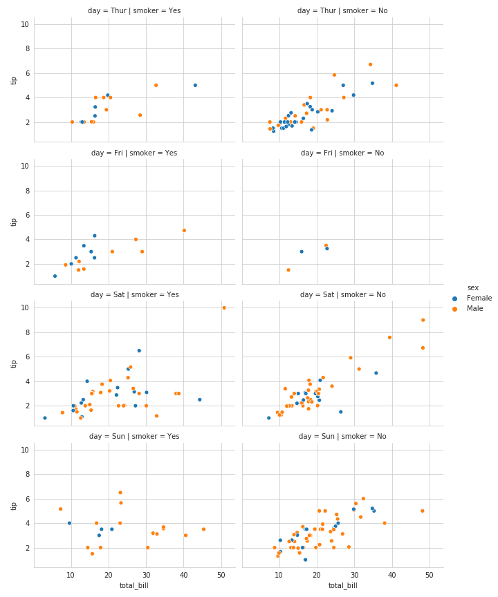

```python
grid = sns.relplot(x='total_bill', y='tip', row='day',
                   col='smoker', hue='sex', data=tips,
                   kind='scatter', height=3, aspect=1.5)
```

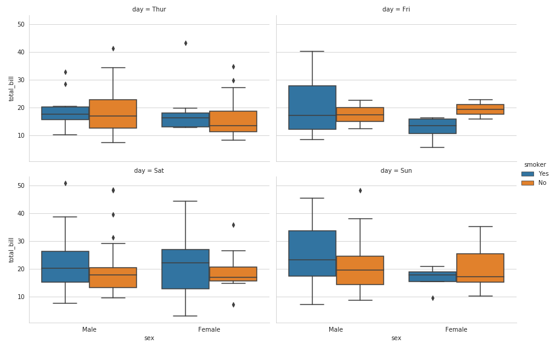

```python
grid = sns.catplot(x='sex', y='total_bill', col='day', col_wrap=2,
                   hue='smoker', data=tips, kind='box', height=4, aspect=1.5)
```

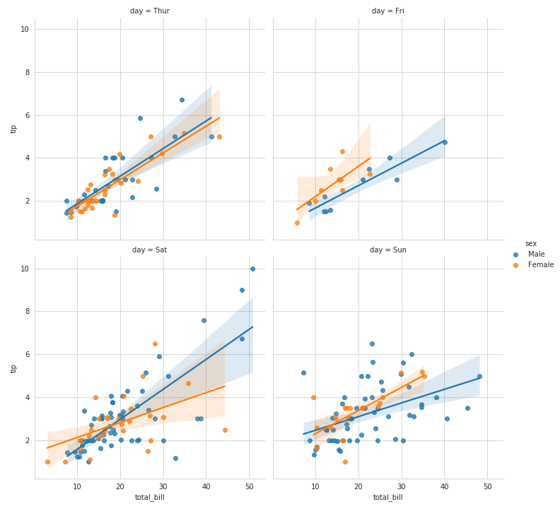

```python
grid = sns.lmplot(x='total_bill', y='tip', col='day', col_wrap=2, hue='sex', data=tips)
```

# Seaborn: Figure Level Functions

## FacetGrid

- Each of the above three figure level functions as well as `FacetGrid` returns an instance of `FacetGrid`.
- Using `FacetGrid` instance, we can get access to individual **Axes** which can then be used to tweak the plot (like adding axis labels, titles etc).
- Also, controlling the size of figure level functions is different compared to controlling the size of **matplotlib** figures.
- Instead of setting the overall figure size, we can set the height and aspect of each **Facet (subplot)** using the `height` and `aspect` parameters.

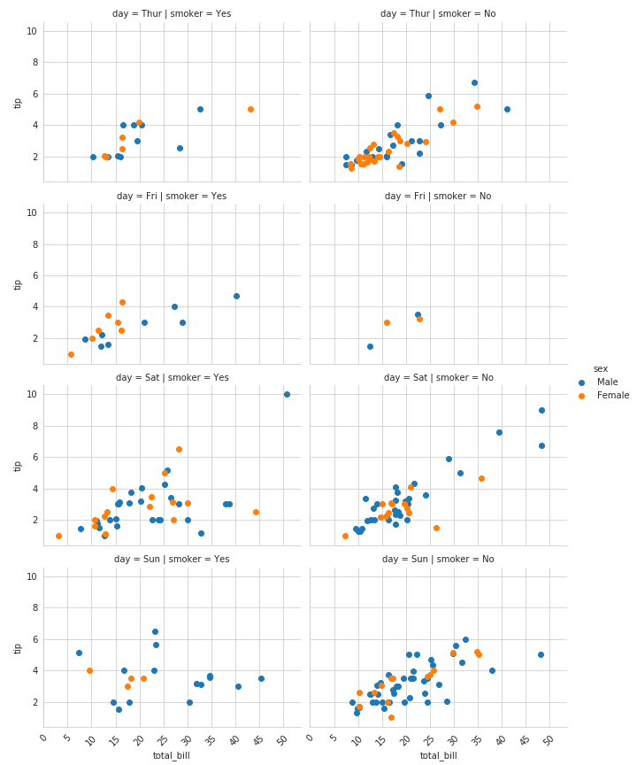

```python
facet_grid = sns.FacetGrid(row='day', col='smoker', hue='sex',
                           data=tips, height=3, aspect=1.5)
facet_grid = facet_grid.map(plt.scatter, 'total_bill','tip')
facet_grid = facet_grid.add_legend()
all_axes = facet_grid.axes
for ax in all_axes.flatten():
    ax.set_xticks(np.arange(0,55,5))
    ax.tick_params('x', labelrotation=45)
```

# Seaborn: Figure Level Functions

## PairGrid

- `PairGrid` is used to plot pairwise relationships between variables in a dataset.
- Each subplot shows a relationship between a pair of variables.
- Consider a following use case, we want to visualise relationship (via scatter plot) between every pair of variables. This can be easily done in `matplotlib` as follows:

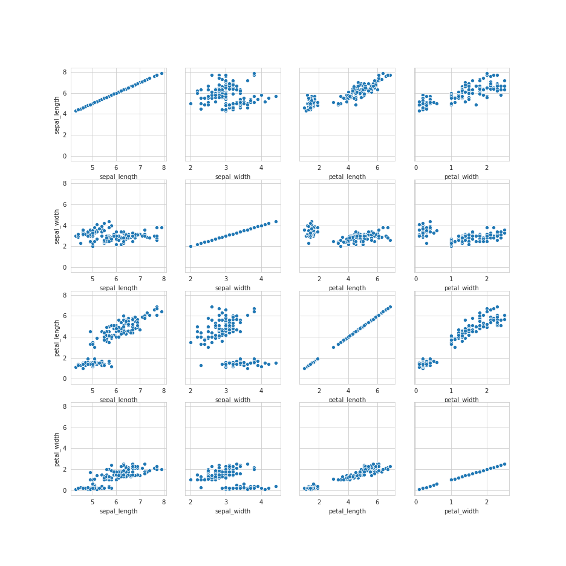

```python
row_variables = iris.columns[:-1]
column_variables = iris.columns[:-1]
num_rows = row_variables.shape[0]
num_columns = column_variables.shape[0]
fig,axes = plt.subplots(num_rows, num_columns, figsize=(13,13), sharey=True)
for i in range(num_rows):
    for j in range(num_columns):
        ax = axes[i][j]
        row_variable = row_variables[i]
        column_variable = column_variables[j]
        sns.scatterplot(x=column_variable, y=row_variable, data=iris, ax=ax)
```

# Seaborn: Figure Level Functions

## PairGrid

- The above code can be broken down into two steps
  - Create an **Axes** for each pair of variables
  - On each **Axes**, draw the scatter plot using the data
  - corresponding to that pair of variables
- Step 1 can be done using `PairGrid()`
- Step 2 can be done using `PairGrid.map()`
- Thus `PairGrid()` creates **Axes** for each pair of variables and `PairGrid.map()` draws the plot on each **Axes** using data corresponding to that pair of variables.
- We can pass different **Axes-level** function to `PairGrid.map()`

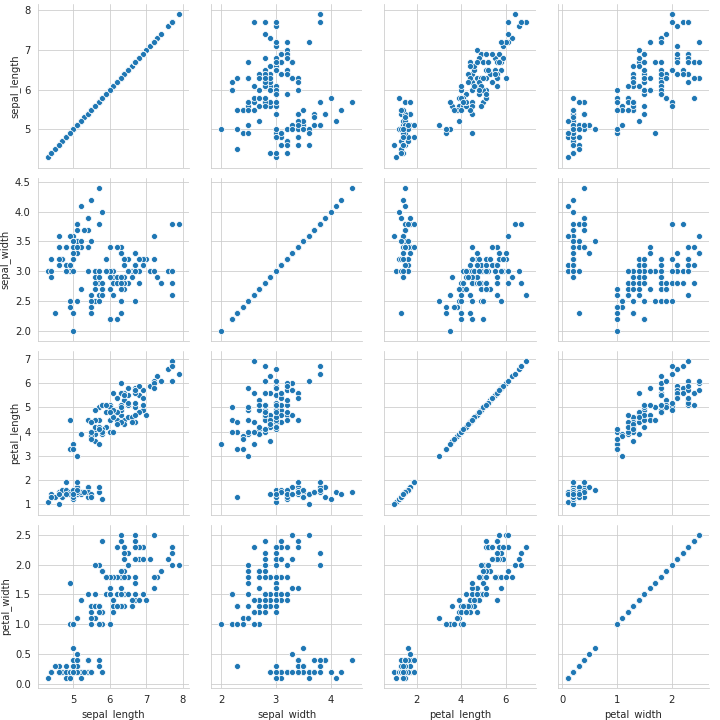

```python
pairgrid = sns.PairGrid(data=iris)
pairgrid = pairgrid.map(sns.scatterplot)
```

# Seaborn: Figure Level Functions

## PairGrid

- It does not make sense to plot a scatter plot on the diagonal **Axes**.
- It is possible to plot one kind of plot on diagonal **Axes** and another kind of plot on non-diagonal **Axes**.

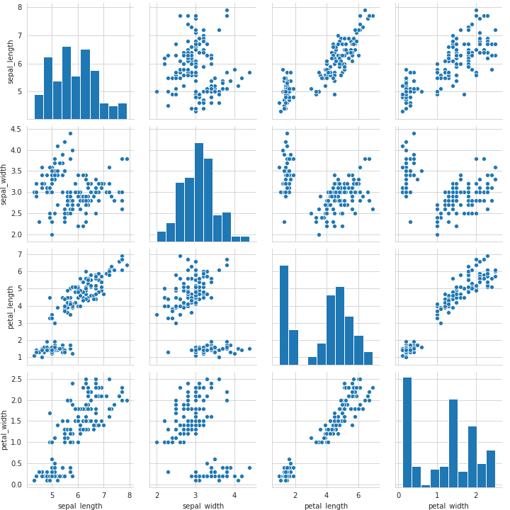

```python
pairgrid = sns.PairGrid(data=iris)
pairgrid = pairgrid.map_offdiag(sns.scatterplot)
pairgrid = pairgrid.map_diag(plt.hist)
```

# Seaborn: Figure Level Functions

## PairGrid

- It is also possible to draw different kind of plots on **Upper Triangular Axes**, **Diagonal Axes** and **Lower Triangular Axes**.

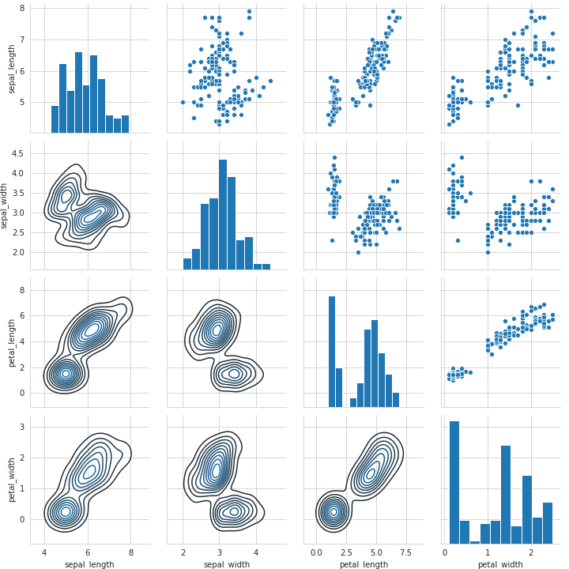

```python
pairgrid = sns.PairGrid(data=iris)
pairgrid = pairgrid.map_upper(sns.scatterplot)
pairgrid = pairgrid.map_diag(plt.hist)
pairgrid = pairgrid.map_lower(sns.kdeplot)
```

# Seaborn: Figure Level Functions

## PairGrid

- **Seaborn** also provides a high level interface `pairplot()` to plot pairwise relationships of variables if you don’t need all the flexibility of `PairGrid()`. It uses `PairGrid()` and `PairGrid.map()` in the background.

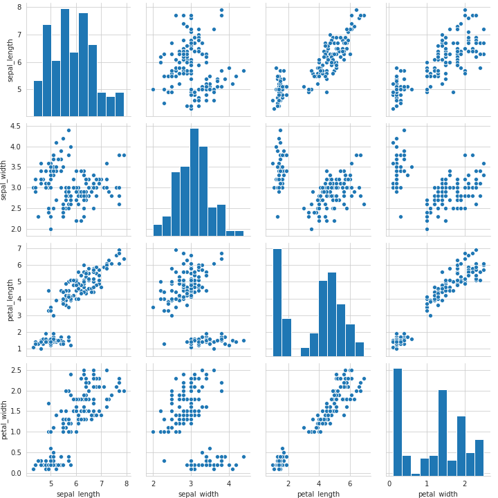

```python
sns.pairplot(data=iris)
```

# Seaborn: Figure Level Functions

## PairGrid

- Both `PairGrid()` and `pairplot()` return an instance of `PairGrid()`.
- Using `PairGrid()` instance, we can get access to individual **Axes** which can then be used to tweak plot like adding axis labels, titles, etc.

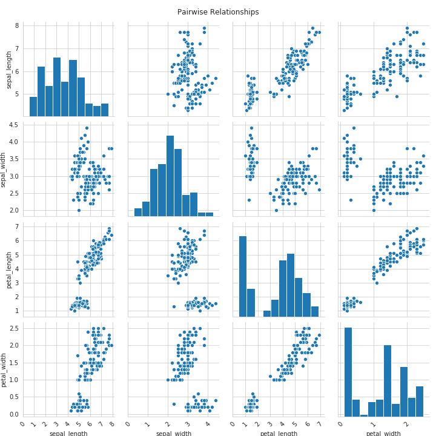

```python
pairgrid = sns.PairGrid(data=iris)
pairgrid = pairgrid.map_offdiag(sns.scatterplot)
pairgrid = pairgrid.map_diag(plt.hist)
all_axes = pairgrid.axes
plt.subplots_adjust(top=0.95)
fig = pairgrid.fig
fig.suptitle('Pairwise Relationships')
for ax in all_axes.flatten():
    xmin, xmax = ax.get_xlim()
    xmin = np.floor(xmin)
    xmin = 0
    xmax = np.ceil(xmax)
    xticks = np.arange(xmin, xmax, 1)
    ax.set_xticks(xticks)
    ax.tick_params('x', labelrotation=45)
```

# Seaborn: Figure Level Functions

## JointGrid

- `JointGrid` is used when we want to plot a **bi-variate distribution** along with **marginal distributions** in the same plot.
- **Joint Distribution** of two variables can be visualised using **scatter plot** / **regplot** or **kdeplot**.
- **Marginal Distribution** of variables can be visualised by **histograms** and/or **kde plot**.
- The **Axes-level** function to use for **joint distribution** must be passed to `JointGrid.plot_joint()`.
- The **Axes-level** function to use for **marginal distribution** must be passed to `JointGrid.plot_marginals()`.

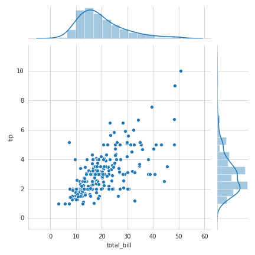

```python
jointgrid = sns.JointGrid(x='total_bill', y='tip', data=tips)
jointgrid.plot_joint(sns.scatterplot)
jointgrid.plot_marginals(sns.distplot)
```

# Seaborn: Figure Level Functions

## JointGrid

- If you don’t need all the flexibility of `JointGrid()`, **seaborn** also provides a high level interface `jointplot()` to plot **bi-variate distribution** along with **marginal distributions**.
- It uses `JointGrid()` and `JointGrid.plot_joint()` in the background.

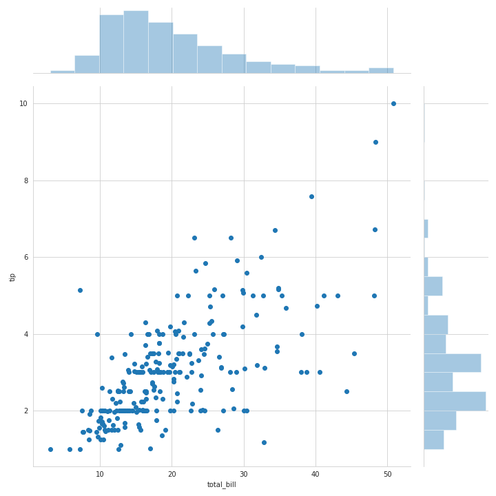

```python
sns.jointplot(x='total_bill', y='tip', data=tips, height=10)
```

# Seaborn: Figure Level Functions

## JointGrid

- Both `JointGrid()` and `jointplot()` return an instance of `JointGrid()`.
- Using `JointGrid()` instance, we can get access to individual **Axes** which can then be used to tweak plots like adding labels, title, etc.

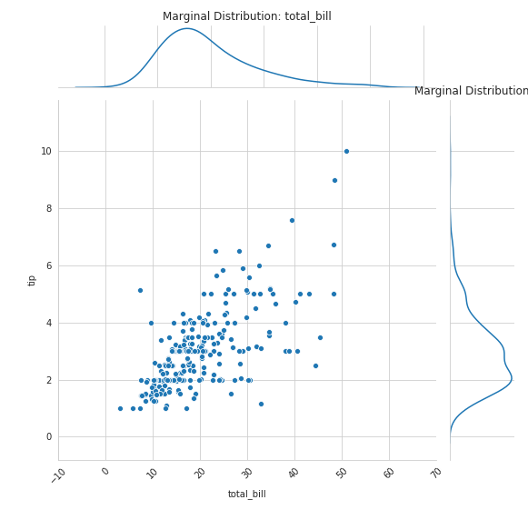

```python
jointgrid = sns.JointGrid(x='total_bill', y='tip', data=tips)
jointgrid.plot_joint(sns.scatterplot)
jointgrid.plot_marginals(sns.kdeplot)
plt.subplots_adjust(top=0.95)
jointgrid.ax_marg_x.set_title('Marginal Distribution: total_bill')
jointgrid.ax_marg_y.set_title('Marginal Distribution: tip')
jointgrid.ax_joint.set_xticks(np.arange(-10,80,10))
jointgrid.ax_joint.tick_params('x', labelrotation=45)
```

# Summary

- Integration of **seaborn** with **pandas** helps in making complex multidimensional plots with minimal code.
- Each plotting function in **seaborn** is either an **Axes-level** function or a **figure-level** function.
- An **Axes-level** function draws onto a single **matplotlib** **Axes** and does not effect the rest of the figure.
- A **figure-level** function, on the other hand, controls the entire figure.
- Heres is a quick summary for **Axes-level** and **Figure-level** functions

## Axes Level Functions

- **Relational Plots**

  > `scatterplot()`  
  > `lineplot()`
- **Categorical Plots**

  > `striplot()`  
  > `swarmplot()`  
  > `boxplot()`  
  > `boxenplot()`  
  > `violinplot()`  
  > `countplot()`  
  > `pointplot()`  
  > `barplot()`
- **Distribution Plots**

  > `distplot()`  
  > `kdeplot()`  
  > `rugplot()`
- **Regression Plots**

  > `regplot()`  
  > `residplot()`
- **Matrix Plots**

  > `heatmap()`

## Figure Level Functions

> `FacetGrid`

> > `relplot()`

> > > `FacetGrid()` + `lineplot()` / `scatterplot()`

> > > `catplot()`  
> > > `FacetGrid()` + `stripplot()` / `swarmplot()` / `boxplot()` / `boxenplot()` / `violinplot()` / `pointplot()` / `barplot()` / `countplot()`

> > > `lmplot()`  
> > > `FacetGrid()` + `regplot()`

> `Pairgrid`

> > `pairplot()`

> `JointGrid`

> > `jointplot()`